# 2.3 — Cost Minimization — Practice Problems (Solutions)

ECON 306

Your firm can use labor $l$ and capital $k$ to produce output according to the production function:
$$q=4lk$$

The marginal products are:

$$\begin{aligned}
MP_l &=4k \\
MP_k &=4l \\ \end{aligned}$$

Suppose you need to produce 144 units, the price of labor is $10, and the price of capital is $40.

### 1. What is the least-cost combination of labor and capital that produces 144 units of output?

Use the definition of the optimum:

$$\begin{align*}
MRTS_{l,k}&=\frac{w}{r} & & \text{Definition of the optimum}\\
\frac{MP_l}{MP_k}&=\frac{w}{r} && \text{Definition of MRTS on left}\\
\frac{4k}{4l} &=\frac{(10)}{(40)} & & \text{Plugging in what we know}\\
\frac{k}{l}&=\frac{1}{4} && \text{Simplifying}\\
k&=\frac{1}{4}l && \text{Multiplying both sides by} l\\
\end{align*}$$

So we know that we will be using 1 unit of capital for every 4 workers (this should make sense, as capital is 4 times as expensive as labor). This is the optimal ratio of inputs.

To find the exact quantities of $l$ and $k$, use the production function:

$$\begin{align*}
q&=4lk & & \text{The production function}\\
144&=4l(\frac{1}{4}l) & & \text{Plugging in what we are given and what we found}\\
144&=l^2 & & \text{Multiplying}\\
12&=l & & \text{Square rooting both sides}\\
\end{align*}$$

Now that we know the quantity of labor, we can use our knowledge of the ratio of labor to capital to find the optimal quantity of capital.
$$\begin{align*}
k&=\frac{1}{4}l\\
k&=\frac{1}{4}(12)\\
k&=3\\
\end{align*}$$

So using 12 workers and 3 units of capital produces 144 units of output at the lowest total cost.

### 2. How much does this combination cost?

$$\begin{align*}
wl+rk&=C && \text{The isocost line equation}\\
10(12)+40(3)&=C && \text{Plugging in what we know (prices) and what we found}\\
120+120&=C && \text{Multiplying}\\
240&=C && \text{Adding}\\
\end{align*}$$

The total cost of using 12 workers and 3 units of capital at current prices is $240.

### 3. Does this technology experience constant returns, increasing returns, or decreasing returns to scale?

Simply plug in combinations of labor and capital that change at the same rate, and see at what rate output changes. For example, with 1 worker, 1 unit of capital, output is:

$$\begin{align*}
q&=4lk\\
q&=4(1)(1)\\
q&=4
\end{align*}$$

If we now *double* all inputs, so that we use 2 workers and 2 units of capital, output is

$$\begin{align*}
q&=4lk\\
q&=4(2)(2)\\
q&=16
\end{align*}$$

Output has quadrupled from 4 to 16, from a doubling of all inputs. Therefore, this technology exhibits increasing returns to scale.

There is a shortcut that we could use, because this function is in Cobb-Douglas format (inputs are *multiplied* by each other, and each raised to an exponent), we can simply sum the exponents:

$$q=4l^{1}k^{1}$$
$$1+1=2$$

Because the exponents sum to a number greater than one, this technology is increasing returns. Be careful, this shortcut method *only* works for Cobb-Douglas functions!

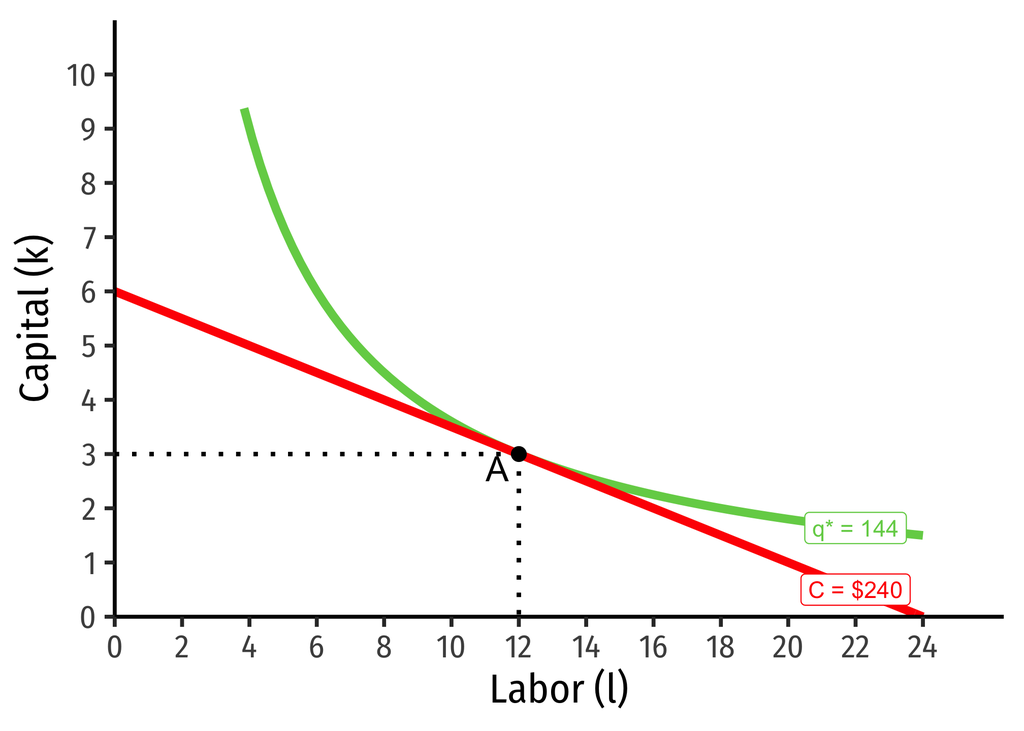